# Bellabeat Marketing Analysis

sunavya varagani

2024-11-26

# Introduction

# Data Loading and Preprocessing

First, we load the datasets and perform the necessary cleaning steps.

# Load the necessary libraries

```r
library(dplyr)
```

```r
library(ggplot2)
```

# Set working directory (adjust the path to where your data is stored)

```r
setwd("C:/Users/030825130/OneDrive - csulb/Desktop/merged")
```

# Load the daily activity data and sleep day

```r
setwd(file.path("C:", "Users", "030825130", "OneDrive - csulb", "Desktop", "merged"))
daily_activity <- read.csv("dailyActivity_merged.csv")
sleep_day <- read.csv("sleepDay_merged.csv")
```

# Check the first few rows of the daily activity data

```r
head(daily_activity)
```

```
##           Id ActivityDate TotalSteps TotalDistance TrackerDistance
## 1 1503960366    3/25/2016      11004          7.11            7.11
## 2 1503960366    3/26/2016      17609         11.55           11.55
## 3 1503960366    3/27/2016      12736          8.53            8.53
## 4 1503960366    3/28/2016      13231          8.93            8.93
## 5 1503960366    3/29/2016      12041          7.85            7.85
## 6 1503960366    3/30/2016      10970          7.16            7.16
##   LoggedActivitiesDistance VeryActiveDistance ModeratelyActiveDistance
## 1                        0               2.57                     0.46
## 2                        0               6.92                     0.73
## 3                        0               4.66                     0.16
## 4                        0               3.19                     0.79
## 5                        0               2.16                     1.09
## 6                        0               2.36                     0.51
##   LightActiveDistance SedentaryActiveDistance VeryActiveMinutes
## 1                4.07                       0                33
## 2                3.91                       0                89
## 3                3.71                       0                56
## 4                4.95                       0                39
## 5                4.61                       0                28
## 6                4.29                       0                30
##   FairlyActiveMinutes LightlyActiveMinutes SedentaryMinutes Calories
## 1                  12                  205              804     1819
## 2                  17                  274              588     2154
## 3                   5                  268              605     1944
## 4                  20                  224             1080     1932
## 5                  28                  243              763     1886
## 6                  13                  223             1174     1820
```

# Check the first few rows of the sleep data

```r
head(sleep_day)
```

```
##           Id              SleepDay TotalSleepRecords TotalMinutesAsleep
## 1 1503960366 4/12/2016 12:00:00 AM                 1                327
## 2 1503960366 4/13/2016 12:00:00 AM                 2                384
## 3 1503960366 4/15/2016 12:00:00 AM                 1                412
## 4 1503960366 4/16/2016 12:00:00 AM                 2                340
## 5 1503960366 4/17/2016 12:00:00 AM                 1                700
## 6 1503960366 4/19/2016 12:00:00 AM                 1                304
##   TotalTimeInBed
## 1            346
## 2            407
## 3            442
## 4            367
## 5            712
## 6            320
```

# Data Cleaning and Preprocessing

```r
# Remove rows with NA values
daily_activity_clean <- na.omit(daily_activity)
sleep_day_clean <- na.omit(sleep_day)

# Handle missing values by replacing NAs with the mean
daily_activity_clean$TotalSteps[is.na(daily_activity_clean$TotalSteps)] <- mean(daily_activity_clean$TotalSteps, na.rm = TRUE)
sleep_day_clean$TotalMinutesAsleep[is.na(sleep_day_clean$TotalMinutesAsleep)] <- mean(sleep_day_clean$TotalMinutesAsleep, na.rm = TRUE)

# Convert ActivityDate and SleepDay columns to Date type
daily_activity_clean$ActivityDate <- as.Date(daily_activity_clean$ActivityDate, format="%m/%d/%Y")
sleep_day_clean$SleepDay <- as.Date(sleep_day_clean$SleepDay, format="%m/%d/%Y")

# Create a new variable for activity level based on steps
daily_activity_clean <- daily_activity_clean %>%
  mutate(ActivityLevel = case_when(
    TotalSteps < 5000 ~ "Low Activity",
    TotalSteps >= 5000 & TotalSteps <= 10000 ~ "Medium Activity",
    TotalSteps > 10000 ~ "High Activity"
  ))

# Check for any remaining missing values after cleaning
colSums(is.na(daily_activity_clean))
```

```
##                       Id             ActivityDate               TotalSteps
##                        0                        0                        0
##            TotalDistance          TrackerDistance LoggedActivitiesDistance
##                        0                        0                        0
##       VeryActiveDistance ModeratelyActiveDistance      LightActiveDistance
##                        0                        0                        0
##  SedentaryActiveDistance        VeryActiveMinutes      FairlyActiveMinutes
##                        0                        0                        0
##     LightlyActiveMinutes         SedentaryMinutes                 Calories
##                        0                        0                        0
##            ActivityLevel
##                        0
```

```r
colSums(is.na(sleep_day_clean))
```

```
##                 Id           SleepDay  TotalSleepRecords TotalMinutesAsleep
##                  0                  0                  0                  0
##     TotalTimeInBed
##                  0
```

```r
# Merging the cleaned daily activity and sleep data
combined_data_clean <- merge(daily_activity_clean, sleep_day_clean, by = "Id")

# Check the structure of the merged dataset
head(combined_data_clean)
```

```
##           Id ActivityDate TotalSteps TotalDistance TrackerDistance
## 1 1503960366   2016-04-09      12432           8.1             8.1
## 2 1503960366   2016-04-09      12432           8.1             8.1
## 3 1503960366   2016-04-09      12432           8.1             8.1
## 4 1503960366   2016-04-09      12432           8.1             8.1
## 5 1503960366   2016-04-09      12432           8.1             8.1
## 6 1503960366   2016-04-09      12432           8.1             8.1
##   LoggedActivitiesDistance VeryActiveDistance ModeratelyActiveDistance
## 1                        0               2.59                     0.59
## 2                        0               2.59                     0.59
## 3                        0               2.59                     0.59
## 4                        0               2.59                     0.59
## 5                        0               2.59                     0.59
## 6                        0               2.59                     0.59
##   LightActiveDistance SedentaryActiveDistance VeryActiveMinutes
```

[output cut: 20 more lines]

# 1. Steps vs Sedentary Minutes (Scatter Plot)

The “Steps vs Sedentary Minutes” scatter plot reveals the relationship between physical activity and sedentary behavior. If more active individuals tend to spend less time sedentary, Bellabeat can leverage this insight to promote their products as tools for reducing sedentary behavior and encouraging a more active lifestyle.

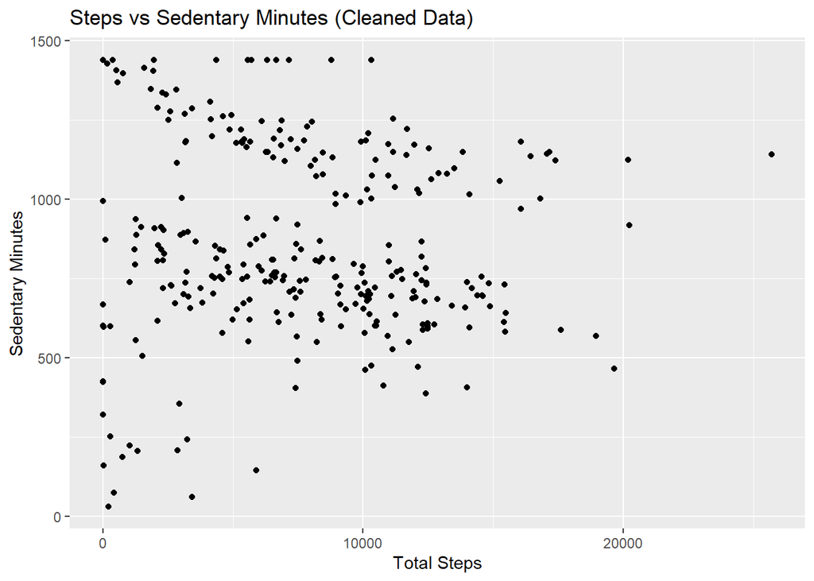

```r
ggplot(data=combined_data_clean, aes(x=TotalSteps, y=SedentaryMinutes)) +
  geom_point() +
  labs(title="Steps vs Sedentary Minutes (Cleaned Data)", x="Total Steps", y="Sedentary Minutes")
```

# 2. Minutes Asleep vs Time in Bed (Scatter Plot)

This scatter plot shows the relationship between Total Minutes Asleep and Total Time in Bed. More time in bed generally leads to more sleep, so this visualization will help Bellabeat understand the connection between sleep habits and product usage.

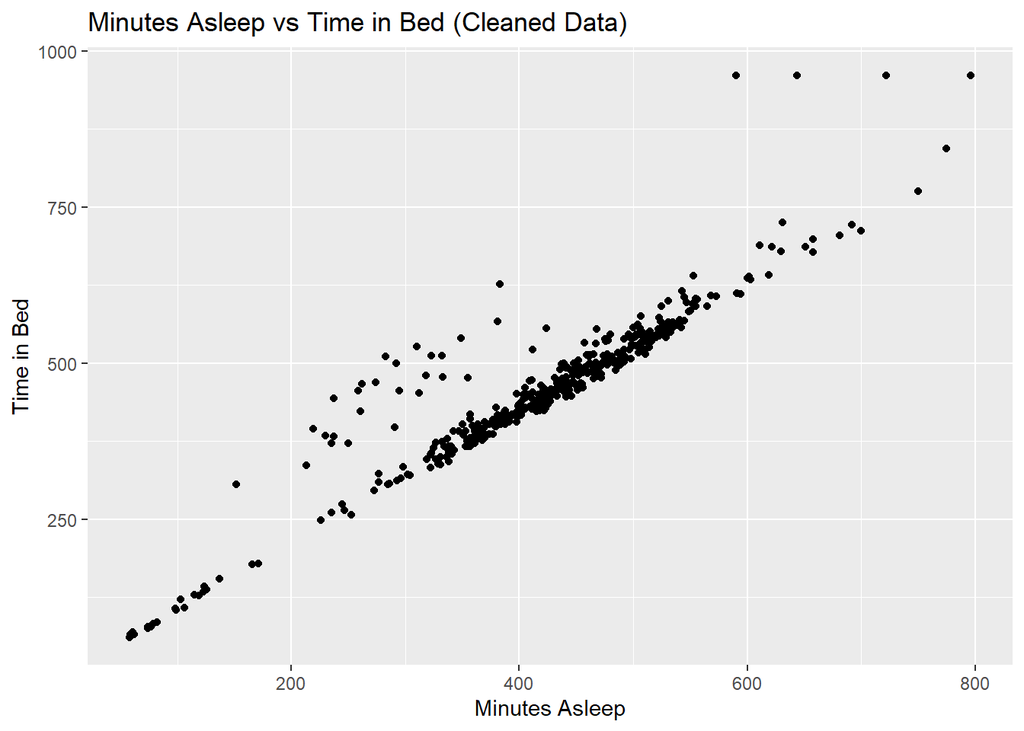

```r
ggplot(data=sleep_day_clean, aes(x=TotalMinutesAsleep, y=TotalTimeInBed)) +
  geom_point() +
  labs(title="Minutes Asleep vs Time in Bed (Cleaned Data)", x="Minutes Asleep", y="Time in Bed")
```

# 3. Sedentary Minutes by Activity Level (Box Plot)

This box plot shows the distribution of Sedentary Minutes by Activity Level (Low, Medium, High). By categorizing users based on their activity levels, we can see how sedentary behavior varies across different activity categories. This will help inform marketing strategies for targeting Low Activity users with campaigns to increase their steps and activity levels.

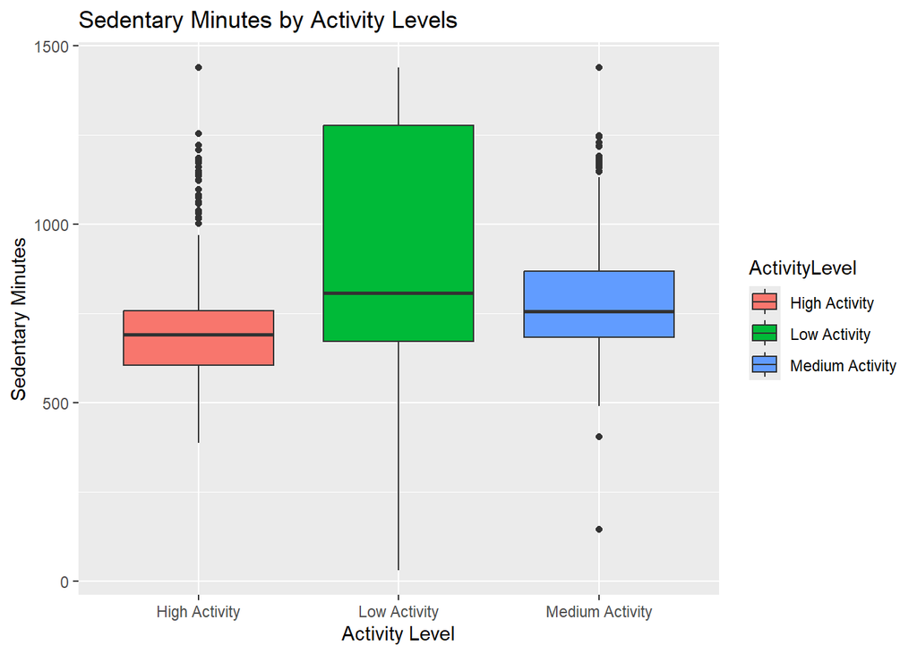

```r
ggplot(data=combined_data_clean, aes(x=ActivityLevel, y=SedentaryMinutes, fill=ActivityLevel)) +
  geom_boxplot() +
  labs(title="Sedentary Minutes by Activity Levels", x="Activity Level", y="Sedentary Minutes")
```

# 4. Steps vs Calories Burned (Scatter Plot)

This scatter plot shows the relationship between Total Steps and Calories Burned, highlighting how more activity leads to higher calorie burn. It can help Bellabeat market its products as effective tools for supporting fitness and weight management.

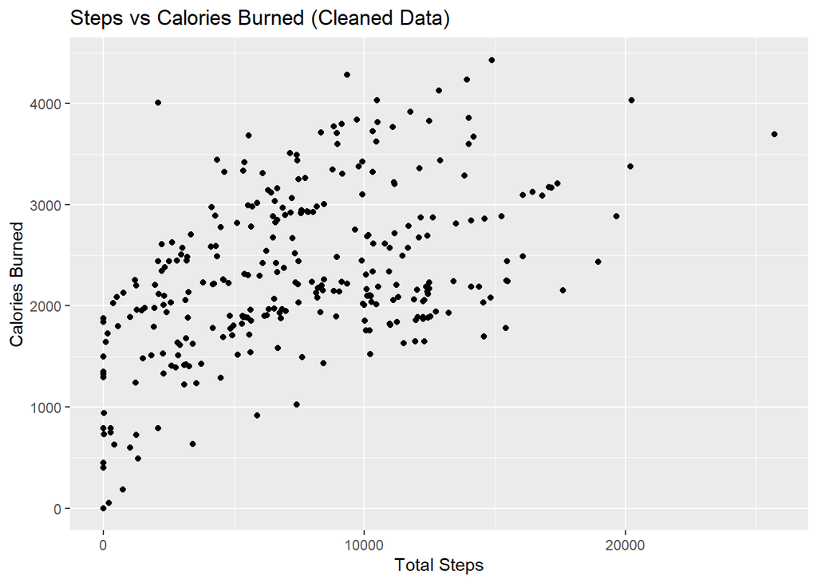

```r
ggplot(data=combined_data_clean, aes(x=TotalSteps, y=Calories)) +
  geom_point() +
  labs(title="Steps vs Calories Burned (Cleaned Data)", x="Total Steps", y="Calories Burned")
```

# Conclusion:

The visualizations reveal key insights for Bellabeat’s marketing strategy:

**1. Steps vs Sedentary Minutes:** More active individuals spend less time sedentary, suggesting Bellabeat products can help reduce sedentary behavior.  
**2. Minutes Asleep vs Time in Bed:** More time in bed leads to more sleep, indicating Bellabeat’s products can support better sleep habits.  
**3. Sedentary Minutes by Activity Level:** Low-activity users tend to be more sedentary, providing an opportunity to target them with activity-boosting campaigns.  
**4. Steps vs Calories Burned:** Increased steps lead to higher calorie burn, emphasizing Bellabeat products as effective tools for fitness and weight management.

These insights help guide targeted marketing and product development.